# Atividade Diagrama de Lexis

Hermes Jasper Winarski - 190029498

### Questão 1

#### **Represente no Diagrama de Lexis as seguintes informações e identifique os anos de nascimento das crianças analisadas:**

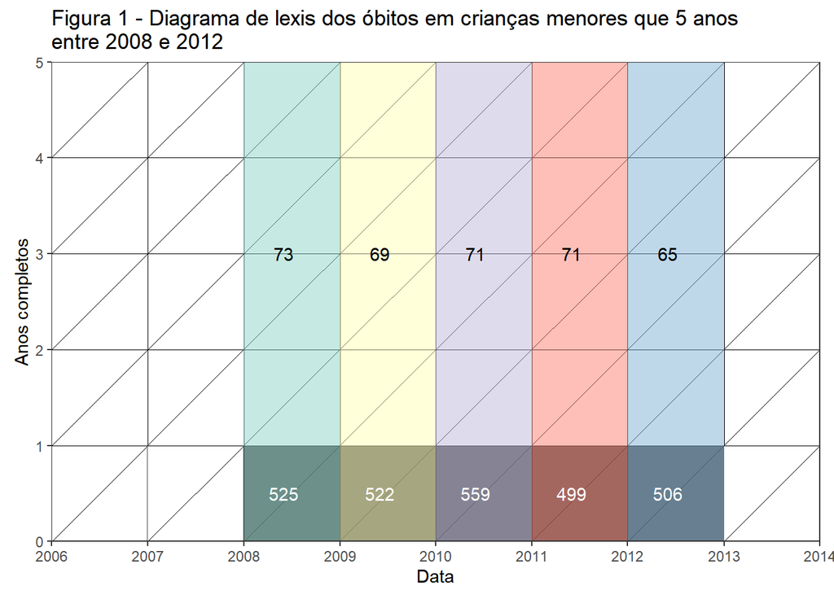

#### *A Pesquisa alcança crianças que tiveram o nascimento no intervalo de 01/01/2003 até 31/12/2012.*

### Questão 2

#### **Com base nas informações contidas no Diagrama de Lexis (FIG. 1) construído para o Estado de Tocantins calcule:**

#### **(a)** Supondo população fechada (inexistência de migração), calcule a probabilidade de um recém-nascido no Estado de Tocantins sobreviver à idade exata 5 para as coortes de 1999 a 2002;

#### **(b)** Considerando o mesmo pressuposto da letra (a), calcule a probabilidade de sobreviver ao primeiro aniversário dos recém-nascidos no período de 1999 a 2006;

#### **(c)** Comente os resultados encontrados.

Tabela 1 - Probabilidade de crianças nascidas no estado de Tocantins de até 5 anos exatos de idade sobreviverem por Corte

|  | Probabilidade |
| --- | --- |
| Corte 1999 | 97.287% |
| Corte 2000 | 97.401% |
| Corte 2001 | 97.549% |
| Corte 2002 | 97.629% |

Tabela 2 - Probabilidade de crianças nascidas no estado de Tocantins de até 1 ano exato de idade sobreviverem por Corte

|  | Probabilidade |
| --- | --- |
| Corte 1999 | 97.732% |
| Corte 2000 | 97.760% |
| Corte 2001 | 97.933% |
| Corte 2002 | 97.960% |
| Corte 2003 | 98.104% |
| Corte 2004 | 98.138% |
| Corte 2005 | 98.229% |
| Corte 2006 | 98.271% |

#### *A Tabela 1 mostra uma certa tendência de aumentar a probabilidade de sobrevivência conforme o ano de nascimento também aumenta.*

#### *Resultando na mesma conclusão, todas as probabilidades de sobrevivência de bebês de até 1 ano de idade (Tabela 2) têm maior probabilidade de sobrevivência conforme o ano de nascimento é mais recente,*

### Questão 3

#### **Considere a seguinte distribuição de óbitos segundo o ano de nascimento e a idade em 1995 para um determinado país da América Latina**

#### **(a)** Coloque os dados num Diagrama de Lexis

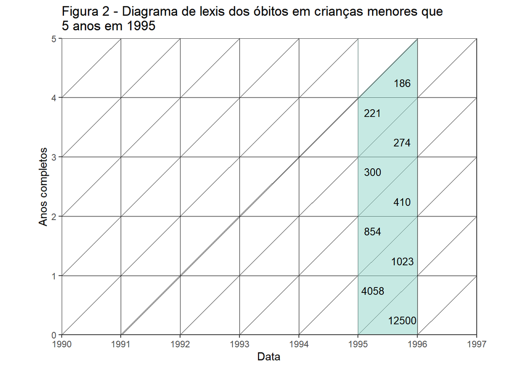

#### **(b)** Se, em 1995, nasceram 100.000 crianças e, se, no início do ano de 1995, foram contadas 85.000 crianças com 0 anos completos, 80.000 com 1 ano completo, 78.000 com 2 anos completos, 76.500 com 3 anos completos e 74.700 com 4 anos completos, quantos crianças com idades entre 0 e 4 anos completos serão contadas no final de 1995?

```r
total_criancas_vivas <- (100000 - 12500) + (85000 - 4058 - 1023) + (80000 - 854 - 410) + (78000 - 300 - 274) + (76500 - 221 - 186)
```

#### *O total de crianças vivas entre 0 e 4 anos completos no final de 1995 é de 399674.*

### Questão 4

#### **Uma pesquisa realizada em 2014, com data de referência 01 de agosto às 0h, levantou dados sobre a vida reprodutiva de mulheres com idades entre 50 e 54 anos. Para essas 500 mulheres amostradas, obtiveram-se os seguintes dados sobre o momento de nascimento de seus filhos.**

#### **a)** Construa o Diagrama de Lexis para os dados acima

#### **b)** Determine o momento calendário de nascimentos dos filhos quando as mulheres tinham entre 20 e 24 anos completos.

#### **c)** Considerando que essas mulheres já encerraram suas experiências reprodutivas, qual o número médio de filhos tidos nascidos vivos ao longo de suas vidas?

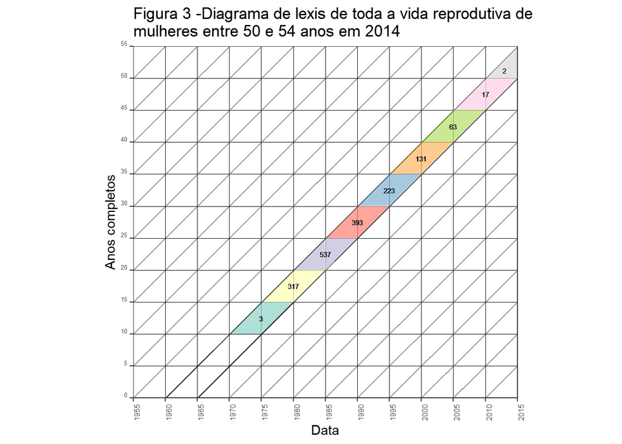

##### *O momento calendário desses nascimentos quando as mães tinham entre 20 a 24 anos completos é todo espaço pintado de roxo na Figura 3, que representa todos os nascimentos (de filhos de mães entrevistadas) de 1980 até 1990 quando elas tinham essa idade.*

##### *O número médio de filhos nascidos vivos ao longo da vida reprodutiva das mulheres entrevistadas é de 3,37.*